# Podatkovno progamiranje Tutorial 7/Vaje 7

##### Dendrogram

A dendrogram is a diagram representing a tree. In hierarchical clustering, it illustrates the arrangement of the clusters produced by the corresponding analyses.

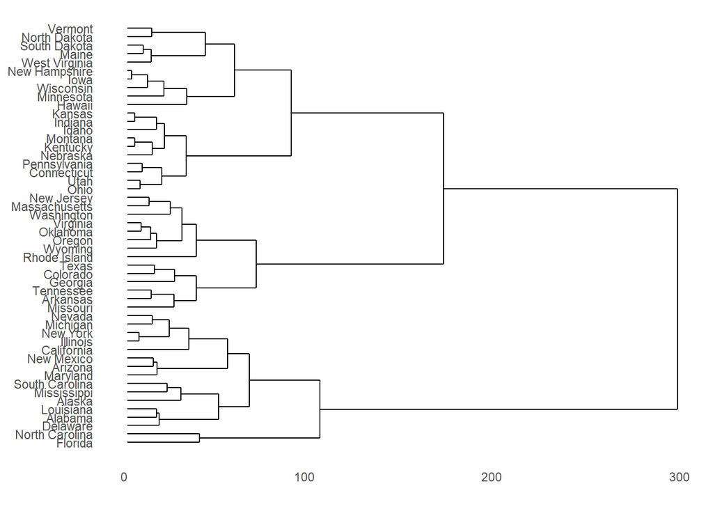

```r
library(ggdendro)
hc <- hclust(dist(USArrests))
ggdendrogram(hc, rotate=T)
```

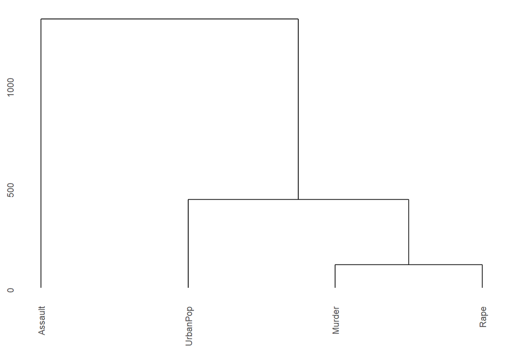

```r
hc2<- hclust(dist(t(USArrests)))
ggdendrogram(hc2, rotate =F)
```

The shorter the path between two variables, the more similar they are.

##### Heat map

A heat map (or heatmap) is a data visualization technique that shows magnitude of a phenomenon as color in two dimensions.

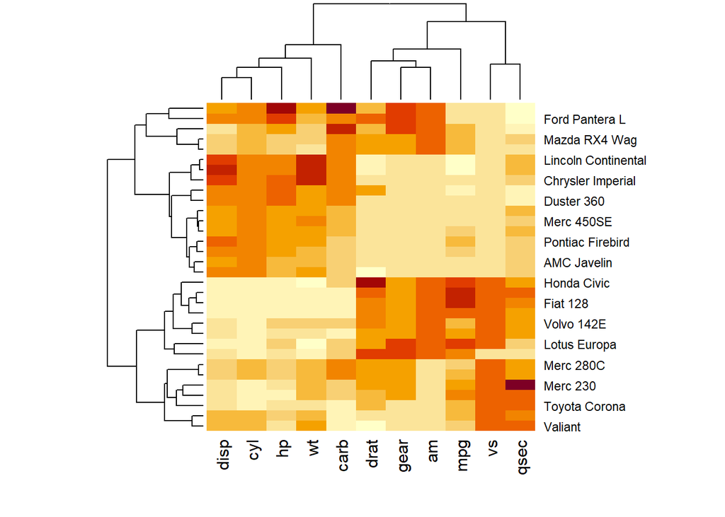

```r
heatmap(scale(mtcars), scale = "none")
```

A similar looking line above, would imply the 2 row variables are similar.

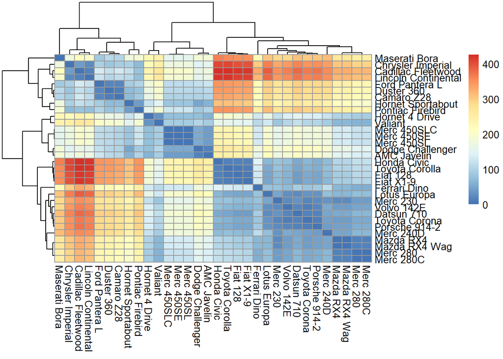

```r
library("pheatmap")
sampleDists<-dist(mtcars)
sampleDistMatrix <- as.matrix(sampleDists)
pheatmap(sampleDistMatrix,
         clustering_distance_rows=sampleDists,
         clustering_distance_cols=sampleDists,
         )
```